# Beer Data Analysis

### 5. Which state has the maximum alcoholic (ABV) beer? Which state has the most bitter (IBU) beer?

```r
#get the maximum ABV by state. Excluding NA's
MaxABVState<-ddply(Stage2, .(State), summarise, MaxABVState = max(ABV, na.rm=TRUE))
#Sort by ABV
MaxABVState<-MaxABVState[order(MaxABVState$MaxABVState),]
#get the maximum IBU by state. Excluding NA's
MaxIBUState<-ddply(Stage2, .(State), summarise, MaxIBUState = max(as.double(Stage2$IBU), na.rm=TRUE))
#Sort by ABV
MaxIBUState<-MaxIBUState[order(MaxIBUState$MaxIBUState),]
```

```r
head(MaxABVState,1)
```

```
##   State MaxABVState
## 9    DE       0.055
```

```r
head(MaxIBUState,1)
```

```
##   State MaxIBUState
## 1    AK         138
```

### 6. Summary statistics for the ABV variable.

> Answer 6

Below are summary statistics for alchohol by volume beers

```r
summary(Stage2$ABV)
```

```
##    Min. 1st Qu.  Median    Mean 3rd Qu.    Max.    NA's
## 0.00100 0.05000 0.05600 0.05977 0.06700 0.12800      62
```

### 7. Is there an apparent relationship between the bitterness of the beer and its alcoholic content? Draw a scatter plot. You are welcome to use the ggplot2 library for graphs. Please ignore missing values in your analysis. Make your best judgment of a relationship and EXPLAIN your answer.

> Answer 7

The chart below indicates that there is possibly a relationship between the bitterness of the beer and its alcoholic content. We must emphasize the word possibly; we would need to know more about the samples before definitively stating there is a relationship.

It seems possible (based on the data provided) that either:

- bitterness influences alchohol content to be higher

or

- alchohol content influences bitterness to be higher.

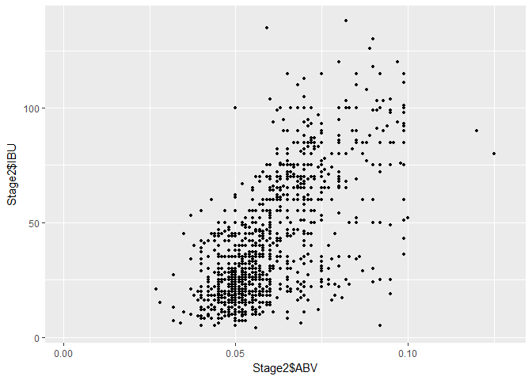

```r
p <- ggplot(Stage2, aes(Stage2$ABV, Stage2$IBU))
p + geom_point(size = 1)
```